# PENS & PRINTERS

Established in 1984, Pens and Printers has emerged as a premier supplier of top-notch office products tailored for large organizations. Our extensive product range spans from high-quality pens and notebooks to ergonomic desk chairs and cutting-edge monitors. While we do not manufacture our own products, we take pride in offering meticulously curated selections from trusted companies, ensuring that our customers receive only the finest solutions.

At Pens and Printers, our foundation is built on enduring relationships with our valued customers. Over the years, we have garnered their trust by consistently delivering excellence and providing products that cater to their specific needs. As the landscape of consumer purchasing evolves, so do our sales strategies. Recognizing the shifting dynamics in the market, we are committed to adapting and innovating to meet the changing needs of our clientele.

Launching a new product line is a strategic venture that demands precision and efficiency. Understanding the evolving nature of consumer behavior, we acknowledge the imperative to refine our sales tactics to effectively introduce and promote new products. We recognize that the most effective approach may vary for each product, prompting us to adopt a dynamic and agile mindset. Our goal is to swiftly discern what strategies prove successful and to continuously refine our methods based on real-time insights.

Pens and Printers remains dedicated to the principles of quality, trust, and adaptability. We look forward to embracing the challenges and opportunities that lie ahead, as we continue to serve as your trusted partner in providing unparalleled office solutions.

```python
#Importing all the packakes that are needed
import pandas as pd
import numpy as np
import matplotlib.pyplot as plt
import seaborn as sns
```

```python
# Reading csv file to pandas dataframe
df= pd.read_csv('product_sales.csv')
df
```

|  | week | sales_method | customer_id | nb_sold | revenue | years_as_customer | nb_site_visits | state |
| --- | --- | --- | --- | --- | --- | --- | --- | --- |
| 0 | 2 | Email | 2e72d641-95ac-497b-bbf8-4861764a7097 | 10 | NaN | 0 | 24 | Arizona |
| 1 | 6 | Email + Call | 3998a98d-70f5-44f7-942e-789bb8ad2fe7 | 15 | 225.47 | 1 | 28 | Kansas |
| 2 | 5 | Call | d1de9884-8059-4065-b10f-86eef57e4a44 | 11 | 52.55 | 6 | 26 | Wisconsin |
| 3 | 4 | Email | 78aa75a4-ffeb-4817-b1d0-2f030783c5d7 | 11 | NaN | 3 | 25 | Indiana |
| 4 | 3 | Email | 10e6d446-10a5-42e5-8210-1b5438f70922 | 9 | 90.49 | 0 | 28 | Illinois |
| ... | ... | ... | ... | ... | ... | ... | ... | ... |
| 14995 | 4 | Call | 17267b41-d048-4346-8b90-7f787690a836 | 10 | 50.82 | 0 | 22 | Pennsylvania |
| 14996 | 5 | Call | 09e10d6f-4508-4b27-895e-4db11ce8302b | 10 | 52.33 | 1 | 27 | Kansas |
| 14997 | 1 | Call | 839653cb-68c9-48cb-a097-0a5a3b2b298b | 7 | 34.87 | 4 | 22 | West Virginia |
| 14998 | 6 | Call | e4dad70a-b23b-407c-8bd3-e32ea00fae17 | 13 | 64.90 | 2 | 27 | New Jersey |
| 14999 | 5 | Email + Call | 4e077235-7c17-4054-9997-7a890336a214 | 13 | NaN | 4 | 25 | Illinois |

15000 rows × 8 columns

```python
df.describe
```

[output not shown]

```python
#data types of a dataframe
#lets check that the data types are correct
df.dtypes
```

```
week                   int64
sales_method          object
customer_id           object
nb_sold                int64
revenue              float64
years_as_customer      int64
nb_site_visits         int64
state                 object
dtype: object
```

```python
df.isnull().sum()
```

```
week                    0
sales_method            0
customer_id             0
nb_sold                 0
revenue              1074
years_as_customer       0
nb_site_visits          0
state                   0
dtype: int64
```

## We see that there is a 1074 null values in revenue column, since the mean value's are around the same, when calculating revenue, we can fill the gaps with mean value. Outliers are part of the succes, so they won't be removed from the data

```python
#Mean revenue filling gaps
mean_revenue = df.groupby('nb_sold')['revenue'].transform('mean')
df['revenue'].fillna(mean_revenue, inplace = True)
```

```python
print(df['revenue'].isnull().sum())
```

```
0
```

```python
# Then we can proceed data validation process
# Validate week column
if not pd.api.types.is_numeric_dtype(df['week']):
    print("Error: 'week' column should be numeric.")

# Validate sales_method column
valid_sales_methods = ['Email', 'Email + Call', 'Call']
if not df['sales_method'].isin(valid_sales_methods).all():
    print("Error: 'sales_method' column should have valid values.")

# Validate customer_id column
if not df['customer_id'].apply(lambda x: len(str(x)) > 0).all():
    print("Error: 'customer_id' column should not have empty values.")

# Validate nb_sold column
if not pd.api.types.is_numeric_dtype(df['nb_sold']):
    print("Error: 'nb_sold' column should be numeric.")

# Validate revenue column
if not pd.api.types.is_numeric_dtype(df['revenue']):
    print("Error: 'revenue' column should be numeric.")

# Validate years_as_customer column
if not pd.api.types.is_numeric_dtype(df['years_as_customer']):
    print("Error: 'years_as_customer' column should be numeric.")

# Validate nb_site_visits column
if not pd.api.types.is_numeric_dtype(df['nb_site_visits']):
    print("Error: 'nb_site_visits' column should be numeric.")

us_states = [
    'Alabama', 'Alaska', 'Arizona', 'Arkansas', 'California', 'Colorado', 'Connecticut', 'Delaware', 'Florida', 'Georgia',
    'Hawaii', 'Idaho', 'Illinois', 'Indiana', 'Iowa', 'Kansas', 'Kentucky', 'Louisiana', 'Maine', 'Maryland',
    'Massachusetts', 'Michigan', 'Minnesota', 'Mississippi', 'Missouri', 'Montana', 'Nebraska', 'Nevada', 'New Hampshire',
    'New Jersey', 'New Mexico', 'New York', 'North Carolina', 'North Dakota', 'Ohio', 'Oklahoma', 'Oregon', 'Pennsylvania',
    'Rhode Island', 'South Carolina', 'South Dakota', 'Tennessee', 'Texas', 'Utah', 'Vermont', 'Virginia', 'Washington',
    'West Virginia', 'Wisconsin', 'Wyoming'
]


# Validate state column
valid_states = us_states  # Add valid state values
if not df['state'].isin(valid_states).all():
    print("Error: 'state' column should have valid values.")
```

```
Error: 'sales_method' column should have valid values.
```

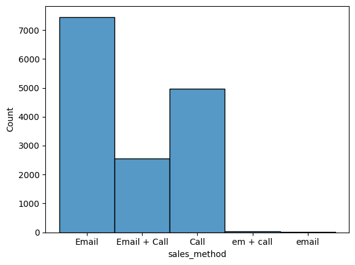

```python
#As we can see, we have few typos on our sales_method column, lets change those
sns.histplot(x='sales_method', data= df)
```

```python
#Correcting typos in data
# First we write dictionary where are values. that we want to replace and values, we're replacing them with
corrections= {
    'em + call': 'Email + Call',
    'email': 'Email'
}
df['sales_method']= df['sales_method'].replace(corrections).str.strip()
```

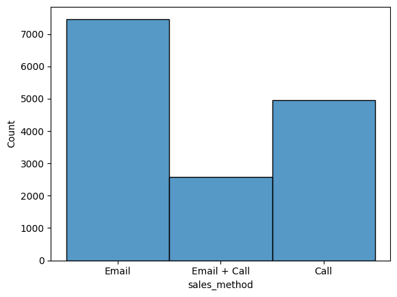

```python
#As we can see, we have few typos on our sales_method column, lets change those
sns.histplot(x='sales_method', data= df)
```

```python
# Creating bins to make Customer Groups starting around 5 years and one group to over 20 years as customer
bin_edges = [-float('inf'), 4, 10, 19, float('inf')]
labels = ["0-4 years", "5-10 years", "11-19 years", "over 20 years"]
df['Customer_groups'] = pd.cut(df['years_as_customer'], bins=bin_edges, labels= labels)
```

# Data forming & Validation

In the end of data preparation section, there were 1074 rows were replaced with mean.

- Also just few typos where in sales_method, so they are too handled
- All the data type was checked
- Added Customer Segments around 5 years

# EDA

questions need to be answered:

- How many customers were there for each approach?
- What does the spread of the revenue look like overall? And for each method?
- Was there any difference in revenue over time for each of the methods?
- Based on the data, which method would you recommend we continue to use? Some of these methods take more time from the team so they may not be the best for us to use if the results are similar.

# How many customers were there for each approach?

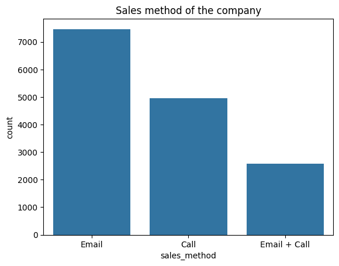

```python
#2k email+ call, almost 5k just call and email contact 7k
sales_method = df['sales_method'].value_counts().index
sns.countplot(x='sales_method', data= df, order= sales_method)
plt.title('Sales method of the company')
```

```python
df['sales_method'].value_counts()
```

```
Email           7466
Call            4962
Email + Call    2572
Name: sales_method, dtype: int64
```

## Total 15 000 Succesfull customer contacts

## - Email was the most used, because it is the fastest to make sales, 7466

## - Second used method was straight calling with 4962

## - third was email + call with 2572

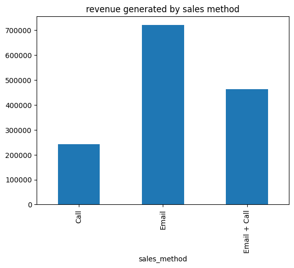

```python
#Over 6 weeks period it seems like email is the strongest one
total_revenue_per_method = df.groupby('sales_method')['revenue'].sum()
total_revenue_per_method.plot(kind='bar')
plt.title('revenue generated by sales method')
```

```python
df.groupby('sales_method')['revenue'].sum()
```

```
sales_method
Call            242452.025730
Email           719227.621965
Email + Call    463724.741982
Name: revenue, dtype: float64
```

## Revenue in percent, with sales Method

### - Email 50%

### - Email + Call 33%

### - Call 17%

## Distribution of methods

### - Email generates most revenue over 700k

### - email+call second largerst over 400k

### - call around 245k

# Was there any difference in revenue over time for each of the methods?

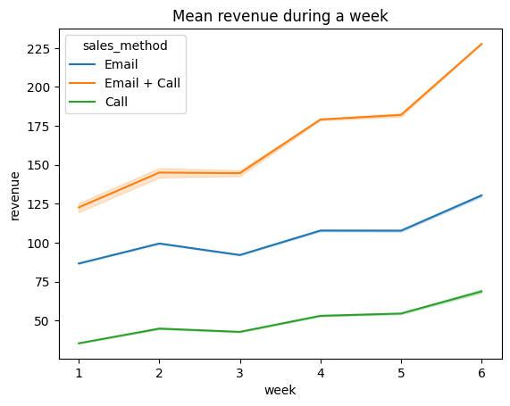

```python
sns.lineplot(y='revenue',x='week', hue='sales_method',data=df)
plt.title('Mean revenue during a week')
```

```python
test= df.groupby('week')['revenue'].sum()
print(test)
```

```
week
1    288859.921225
2    212936.891929
3    196376.588200
4    257852.343915
5    280191.370823
6    189187.273585
Name: revenue, dtype: float64
```

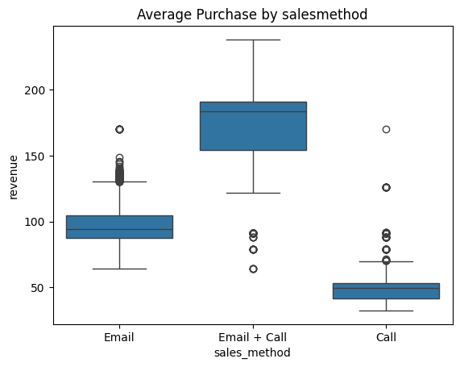

```python
sns.boxplot(y='revenue', x='sales_method', data = df)
plt.title('Average Purchase by salesmethod')
```

## Revenue changes for the methods

- the best revenue generator is Emai+call. mean sell is around 180$
- Second is email with mean around 100$
- third is just call around 50$ Data represents that just callin is the most slow way to make sales, also its least profitable one.

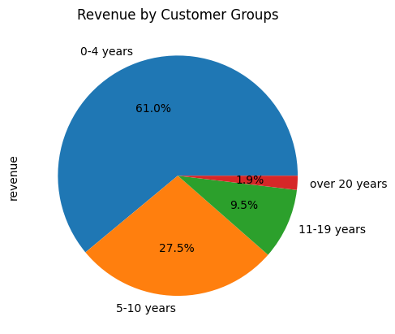

```python
df.groupby('Customer_groups')['revenue'].sum().plot(kind='pie',autopct='%1.1f%%')
plt.title('Revenue by Customer Groups')
plt.show()
```

```python
total_revenueyears = df.groupby('years_as_customer')['revenue'].sum()
print(total_revenueyears. head())
```

```
years_as_customer
0    152258.521675
1    243020.246957
2    190530.623312
3    155709.485852
4    128115.575150
Name: revenue, dtype: float64
```

```python
print(df['Customer_groups'].value_counts())
```

```
0-4 years        8919
5-10 years       4267
11-19 years      1509
over 20 years     305
Name: Customer_groups, dtype: int64
```

```python
#Calculating metrics for time_spent in the work
# Function to calculate time_spent
def calculate_time(method):
    if 'Email+Call' in method:
        return 0.25  # 15 minutes percent of 60
    elif 'Call' in method:
        return 0.5  # 30 minutes percent of 60
    elif 'Email' in method:
        return 0.083  # 5 minutes out of 60
    else:
        return None  # Handle other cases if needed


df['Sale_time'] = df['sales_method'].apply(calculate_time)
percentage_per_method = df.groupby('sales_method')['Sale_time'].sum() / df['Sale_time'].sum() * 100
print(percentage_per_method)
```

```
sales_method
Call            56.557605
Email           14.126362
Email + Call    29.316034
Name: Sale_time, dtype: float64
```

```python
#Calculating Revenue_Per Hour business metric
df['revenue_per_hour'] = df['revenue']/ df['Sale_time']
```

```python
df
```

|  | week | sales_method | customer_id | nb_sold | revenue | years_as_customer | nb_site_visits | state | Customer_groups | Sale_time | revenue_per_hour |
| --- | --- | --- | --- | --- | --- | --- | --- | --- | --- | --- | --- |
| 0 | 2 | Email | 2e72d641-95ac-497b-bbf8-4861764a7097 | 10 | 91.033803 | 0 | 24 | Arizona | 0-4 years | 0.083 | 1096.792802 |
| 1 | 6 | Email + Call | 3998a98d-70f5-44f7-942e-789bb8ad2fe7 | 15 | 225.470000 | 1 | 28 | Kansas | 0-4 years | 0.500 | 450.940000 |
| 2 | 5 | Call | d1de9884-8059-4065-b10f-86eef57e4a44 | 11 | 52.550000 | 6 | 26 | Wisconsin | 5-10 years | 0.500 | 105.100000 |
| 3 | 4 | Email | 78aa75a4-ffeb-4817-b1d0-2f030783c5d7 | 11 | 88.441736 | 3 | 25 | Indiana | 0-4 years | 0.083 | 1065.563078 |
| 4 | 3 | Email | 10e6d446-10a5-42e5-8210-1b5438f70922 | 9 | 90.490000 | 0 | 28 | Illinois | 0-4 years | 0.083 | 1090.240964 |
| ... | ... | ... | ... | ... | ... | ... | ... | ... | ... | ... | ... |
| 14995 | 4 | Call | 17267b41-d048-4346-8b90-7f787690a836 | 10 | 50.820000 | 0 | 22 | Pennsylvania | 0-4 years | 0.500 | 101.640000 |
| 14996 | 5 | Call | 09e10d6f-4508-4b27-895e-4db11ce8302b | 10 | 52.330000 | 1 | 27 | Kansas | 0-4 years | 0.500 | 104.660000 |
| 14997 | 1 | Call | 839653cb-68c9-48cb-a097-0a5a3b2b298b | 7 | 34.870000 | 4 | 22 | West Virginia | 0-4 years | 0.500 | 69.740000 |
| 14998 | 6 | Call | e4dad70a-b23b-407c-8bd3-e32ea00fae17 | 13 | 64.900000 | 2 | 27 | New Jersey | 0-4 years | 0.500 | 129.800000 |
| 14999 | 5 | Email + Call | 4e077235-7c17-4054-9997-7a890336a214 | 13 | 125.849634 | 4 | 25 | Illinois | 0-4 years | 0.500 | 251.699267 |

15000 rows × 11 columns

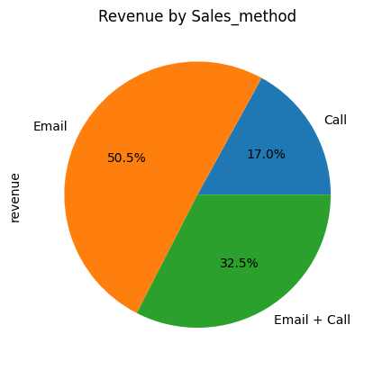

```python
df.groupby('sales_method')['revenue'].sum().plot(kind='pie',autopct='%1.1f%%')
plt.title('Revenue by Sales_method')
plt.show()
```

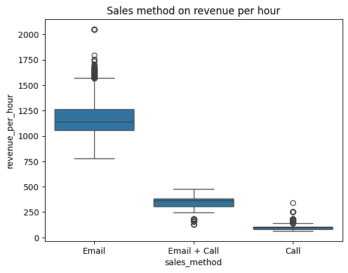

```python
sns.boxplot(x='sales_method',y='revenue_per_hour',data= df)
plt.title('Sales method on revenue per hour')
```

```python
df.groupby('sales_method')['revenue_per_hour'].mean()
```

```
sales_method
Call              97.723509
Email           1160.647339
Email + Call     360.594667
Name: revenue_per_hour, dtype: float64
```

# Revnues per_hour

- Email is the most efficient one clearly generating the most amount of revenue

# CONCLUSION

Furthermore, our analysis indicates that a direct call to customers is the least effective method in terms of both time and revenue. With a call duration of approximately 30 minutes and the associated revenue being the lowest, it is proposed that we consider a modified approach. Specifically, replacing the initial contact method with an email and subsequently following up with a call after a week could prove to be a more effective strategy. This approach not only allows customers to familiarize themselves with our offerings but also provides them with the opportunity to identify their needs. By incorporating a subsequent call, we can address customer queries, enhance satisfaction, and ultimately boost revenue, particularly from our more established customer base.

Calling generates only 17% value,but takes 56% of companys time, we need to focus more on other objectives, such ass call+ email and email